# Multi-objective optimization of robust latent models

Instalation of pymoo library.

```python
!python --version
```

```
Python 3.8.16
```

```python
pip install pymoo
```

[output not shown]

Loading libraries and functions.

```python
import pandas as pd
import numpy as np
from numpy.random.mtrand import seed

import os
import matplotlib.pyplot as plt

from pymoo.algorithms.soo.nonconvex.ga import GA
from pymoo.algorithms.moo.nsga2 import NSGA2
from pymoo.algorithms.moo.nsga3 import NSGA3
from pymoo.algorithms.moo.rvea import RVEA
from pymoo.algorithms.moo.age import AGEMOEA
from pymoo.algorithms.moo.age2 import AGEMOEA2
#from pymoo.core.problem import Problem
from pymoo.optimize import minimize
from pymoo.visualization.scatter import Scatter
from pymoo.factory import get_visualization, get_reference_directions
from pymoo.core.population import Population
from pymoo.core.evaluator import Evaluator
from pymoo.factory import get_decision_making
from pymoo.mcdm.pseudo_weights import PseudoWeights
from pymoo.core.problem import ElementwiseProblem
from pymoo.indicators.hv import Hypervolume
from pymoo.termination import get_termination
from pymoo.operators.crossover.sbx import SBX
from pymoo.operators.mutation.pm import PM
from pymoo.operators.sampling.rnd import FloatRandomSampling

from pymoo.visualization.scatter import Scatter
from pymoo.visualization.heatmap import Heatmap
from pymoo.visualization.pcp import PCP

from pymoo.mcdm.pseudo_weights import PseudoWeights
```

Defining variables, vectors, and matrices for mean and variance functions of PA1.

```python
b0 = -0.6013979

b = np.array([0.06575621, 0.31948919, -0.06714525])

B = np.array([[0.14713902, 0.02559811, 0.02025107],
           [0.02559811, 0.07866396, -0.07615794],
           [0.02025107, -0.07615794, 0.41647644]])

mse = 1.458568

g = np.array([0.3860099, -0.4044974, 0.1854763 ])

D = np.array([[-0.21985622, 0.136971907, 0.05544462],
              [0.02192018, 0.002820816, -0.18664749],
              [-0.15155436, -0.033194321, -0.19947027]])
```

Defining mean of PA1 optimization problem (target of PA1).

```python
class pa1_mean(ElementwiseProblem):

    def __init__(self):
        super().__init__(n_var=3, # numero de parametros
                         n_obj=1, # numero de funcoes objetivos
                         n_constr=1, # numero de restricoes
                         xl=np.array([-(2**3)**0.25, -(2**3)**0.25, -(2**3)**0.25]),
                         xu=np.array([(2**3)**0.25, (2**3)**0.25, (2**3)**0.25])
                         )

    def _evaluate(self, x, out, *args, **kwargs):
      # funcao objetivo
      meanpa1 = b0 + np.matmul(np.transpose([x[0],x[1],x[2]]),b) + np.matmul(np.matmul(np.transpose([x[0],x[1],x[2]]),B),[x[0],x[1],x[2]])

      # restricao
      g1 = x[0]**2 + x[1]**2 + x[2]**2 - ((2**3)**0.25)**2

      out['F'] = [meanpa1]
      out['G'] = [g1]

problem_pa1_mean = pa1_mean()
```

Solving mean of PA1 optimization problem.

```python
algorithm = GA(pop_size=100, eliminate_duplicates=True)

res_target_PA1 = minimize(problem_pa1_mean,
               algorithm,
               seed=1,
               verbose=False)

print("Best solution found: \nX = %s\nF = %s" % (res_target_PA1.X, res_target_PA1.F))

TT = res_target_PA1.F
```

```
Best solution found:
X = [ 0.08582205 -1.66489943 -0.22174669]
F = [-0.93749114]
```

Defining variables, vectors, and matrices for mean and variance functions of PA2.

```python
b02 = 0.04226133

b2 = np.array([0.008277796, 0.362930700, 0.351949737])

B2 = np.array([[-0.02825805, 0.06719915, 0.09672904],
               [0.06719915, -0.02177909, -0.02941881],
               [0.09672904, -0.02941881, -0.08658211]])

mse2 = 1.307646

g2 = np.array([-0.28999529, -0.02568370, -0.05736884])

D2 = np.array([[0.1116691, -0.1020161, -0.14220165],
               [0.1659250, 0.1635910, 0.03733897],
               [-0.1492663, -0.2124864, -0.02881038]])
```

Defining mean of PA2 optimization problem (target of PA2).

```python
class pa2_mean(ElementwiseProblem):

    def __init__(self):
        super().__init__(n_var=3, # numero de parametros
                         n_obj=1, # numero de funcoes objetivos
                         n_constr=1, # numero de restricoes
                         xl=np.array([-(2**3)**0.25, -(2**3)**0.25, -(2**3)**0.25]),
                         xu=np.array([(2**3)**0.25, (2**3)**0.25, (2**3)**0.25])
                         )

    def _evaluate(self, x, out, *args, **kwargs):
      # funcao objetivo
      meanpa2 = b02 + np.matmul(np.transpose([x[0],x[1],x[2]]),b2) + np.matmul(np.matmul(np.transpose([x[0],x[1],x[2]]),B2),[x[0],x[1],x[2]])

      # restricao
      g1 = x[0]**2 + x[1]**2 + x[2]**2 - ((2**3)**0.25)**2

      out['F'] = [meanpa2]
      out['G'] = [g1]

problem_pa2_mean = pa2_mean()
```

Solving mean of PA2 optimization problem.

```python
algorithm = GA(pop_size=100, eliminate_duplicates=True)

res_target_PA2 = minimize(problem_pa2_mean,
               algorithm,
               seed=1,
               verbose=False)

print("Best solution found: \nX = %s\nF = %s" % (res_target_PA2.X, res_target_PA2.F))

TT2 = res_target_PA2.F
```

```
Best solution found:
X = [ 0.61224562 -0.92881165 -1.26130531]
F = [-1.19555476]
```

Defining variables, vectors, and matrices for mean and variance functions of PA3.

```python
b03 = 0.1235535

b3 = np.array([0.1476030, 0.6042446, -0.2713912])

B3 = np.array([[-0.04911806, 0.02617580, -0.07919118],
               [0.02617580, -0.19606180, -0.01440001],
               [-0.07919118, -0.01440001, 0.09426526]])

mse3 = 1.302818

g3 = np.array([-0.06922190, 0.36723319, 0.05824833])

D3 = np.array([[0.11563352, -0.24434165, 0.2187254],
               [0.02033272, -0.14964328, 0.1117455],
               [0.01690157, 0.04164095, -0.1053430]])
```

Defining mean of PA3 optimization problem (target of PA3).

```python
class pa3_mean(ElementwiseProblem):

    def __init__(self):
        super().__init__(n_var=3, # numero de parametros
                         n_obj=1, # numero de funcoes objetivos
                         n_constr=1, # numero de restricoes
                         xl=np.array([-(2**3)**0.25, -(2**3)**0.25, -(2**3)**0.25]),
                         xu=np.array([(2**3)**0.25, (2**3)**0.25, (2**3)**0.25])
                         )

    def _evaluate(self, x, out, *args, **kwargs):
      # funcao objetivo
      meanpa3 = b03 + np.matmul(np.transpose([x[0],x[1],x[2]]),b3) + np.matmul(np.matmul(np.transpose([x[0],x[1],x[2]]),B3),[x[0],x[1],x[2]])

      # restricao
      g1 = x[0]**2 + x[1]**2 + x[2]**2 - ((2**3)**0.25)**2

      out['F'] = [meanpa3]
      out['G'] = [g1]

problem_pa3_mean = pa3_mean()
```

Solving mean of PA3 optimization problem.

```python
algorithm = GA(pop_size=100, eliminate_duplicates=True)

res_target_PA3 = minimize(problem_pa3_mean,
               algorithm,
               seed=1,
               verbose=False)

print("Best solution found: \nX = %s\nF = %s" % (res_target_PA3.X, res_target_PA3.F))

TT3 = res_target_PA3.F
```

```
Best solution found:
X = [-0.03708912 -1.66942903  0.20014546]
F = [-1.47365644]
```

Definition of the three-objective problem of PA1, PA2, and PA3.

```python
class tri_obj(ElementwiseProblem):

    def __init__(self):
        super().__init__(n_var=3, # numero de parametros
                         n_obj=3, # numero de funcoes objetivos
                         n_constr=1, # numero de restricoes
                         xl=np.array([-(2**3)**0.25, -(2**3)**0.25, -(2**3)**0.25]),
                         xu=np.array([(2**3)**0.25, (2**3)**0.25, (2**3)**0.25])
                         )

    def _evaluate(self, x, out, *args, **kwargs):
      # funcoes objetivo
      rmse1 = ((b0 + np.matmul(np.transpose([x[0],x[1],x[2]]),b) + np.matmul(np.matmul(np.transpose([x[0],x[1],x[2]]),B),[x[0],x[1],x[2]]) - TT)**2 + (mse + np.matmul(np.transpose(g + np.matmul(np.transpose(D),[x[0],x[1],x[2]])), (g + np.matmul(np.transpose(D),[x[0],x[1],x[2]])))))**0.5
      rmse2 = ((b02 + np.matmul(np.transpose([x[0],x[1],x[2]]),b2) + np.matmul(np.matmul(np.transpose([x[0],x[1],x[2]]),B2),[x[0],x[1],x[2]]) - TT2)**2 + (mse2 + np.matmul(np.transpose(g2 + np.matmul(np.transpose(D2),[x[0],x[1],x[2]])), (g2 + np.matmul(np.transpose(D2),[x[0],x[1],x[2]])))))**0.5
      rmse3 = ((b03 + np.matmul(np.transpose([x[0],x[1],x[2]]),b3) + np.matmul(np.matmul(np.transpose([x[0],x[1],x[2]]),B3),[x[0],x[1],x[2]]) - TT3)**2 + (mse3 + np.matmul(np.transpose(g3 + np.matmul(np.transpose(D3),[x[0],x[1],x[2]])), (g3 + np.matmul(np.transpose(D3),[x[0],x[1],x[2]])))))**0.5

      # restricao
      g1 = x[0]**2 + x[1]**2 + x[2]**2 - ((2**3)**0.25)**2

      out['F'] = [rmse1, rmse2, rmse3]
      out['G'] = [g1]

problem_tri_obj = tri_obj()
```

Defining algorithm AGEMOEA2 to solve the three-objective problem.

```python
np.random.seed(10)

algorithm = AGEMOEA2(
    pop_size=220,
    n_offsprings=220,
    crossover=SBX(prob=0.9, eta=15),
    mutation=PM(eta=20),
    eliminate_duplicates=True)
```

Solving the three-objective problem.

```python
res_tri = minimize(
  problem_tri_obj,
  algorithm,
  ("n_gen", 100),
  verbose=True,
  seed=1,
  save_history = True)
```

```
==========================================================================================
n_gen  |  n_eval  | n_nds  |     cv_min    |     cv_avg    |      eps      |   indicator
==========================================================================================
     1 |      220 |     10 |  0.000000E+00 |  0.6485434002 |             - |             -
     2 |      440 |     15 |  0.000000E+00 |  0.000000E+00 |  0.1594555236 |         nadir
     3 |      660 |     27 |  0.000000E+00 |  0.000000E+00 |  0.0123416550 |         ideal
     4 |      880 |     48 |  0.000000E+00 |  0.000000E+00 |  0.0078882554 |         ideal
     5 |     1100 |     68 |  0.000000E+00 |  0.000000E+00 |  0.0030016957 |         ideal
     6 |     1320 |    104 |  0.000000E+00 |  0.000000E+00 |  0.0192141787 |         nadir
     7 |     1540 |    169 |  0.000000E+00 |  0.000000E+00 |  0.1131514763 |         nadir
     8 |     1760 |    220 |  0.000000E+00 |  0.000000E+00 |  0.0675811209 |         nadir
     9 |     1980 |    220 |  0.000000E+00 |  0.000000E+00 |  0.0651389871 |         nadir
    10 |     2200 |    220 |  0.000000E+00 |  0.000000E+00 |  0.0074388060 |             f
    11 |     2420 |    220 |  0.000000E+00 |  0.000000E+00 |  0.0027268469 |         nadir
    12 |     2640 |    220 |  0.000000E+00 |  0.000000E+00 |  0.0040280398 |             f
```

[output cut: 88 more lines]

Ploting the Pareto frontier.

```
<pymoo.visualization.scatter.Scatter at 0x7f436f591b20>
```

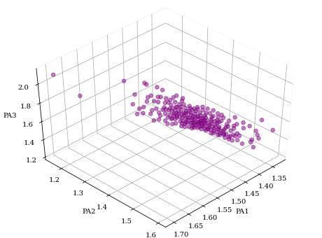

```python
plot = Scatter(labels=["PA1", "PA2", "PA3"])
plot.add(res_tri.F, s= 30, facecolors='purple', edgecolors='purple', alpha = 0.5)
plot.save("front_tri_AGE2.pdf")
plot.show()
```

Evaluating convergence through hypervolume.

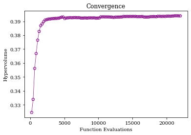

[output not shown]

[output cut: 45 more lines]

[output not shown]

```python
n_evals = []
F = []
cv = []

for algorithm in res_tri.history:
    n_evals.append(algorithm.evaluator.n_eval)
    opt = algorithm.opt
    feas = np.where(opt.get("feasible"))[0]
    _F = opt.get("F")[feas]
    F.append(_F)

ref_point = np.array([2,2,2])
metric = Hypervolume(ref_point=ref_point, normalize=False)
hv = [metric.do(f) for f in F]

plt.figure()
plt.plot(n_evals, hv,  color='purple', lw=0.7, label="Avg. CV of Pop")
plt.scatter(n_evals, hv,  facecolor="none", edgecolor='purple', marker="p")
plt.title("Convergence")
plt.xlabel("Function Evaluations")
plt.ylabel("Hypervolume")
plt.show()

#hv
```

Defining algorithm AGEMOEA to solve the three-objective problem.

```python
np.random.seed(10)

algorithm1 = AGEMOEA(
    pop_size=220,
    n_offsprings=220,
    crossover=SBX(prob=0.9, eta=15),
    mutation=PM(eta=20),
    eliminate_duplicates=True)
```

Solving the three-objective problem.

```python
res1_tri = minimize(
  problem_tri_obj,
  algorithm1,
  ("n_gen", 100),
  verbose=True,
  seed=1,
  save_history = True)
```

```
==========================================================================================
n_gen  |  n_eval  | n_nds  |     cv_min    |     cv_avg    |      eps      |   indicator
==========================================================================================
     1 |      220 |     13 |  0.000000E+00 |  0.6549812232 |             - |             -
     2 |      440 |     21 |  0.000000E+00 |  0.000000E+00 |  0.2808738842 |         nadir
     3 |      660 |     42 |  0.000000E+00 |  0.000000E+00 |  0.0097073673 |         ideal
     4 |      880 |     75 |  0.000000E+00 |  0.000000E+00 |  0.0129916486 |         ideal
     5 |     1100 |     95 |  0.000000E+00 |  0.000000E+00 |  0.0158579134 |         ideal
     6 |     1320 |    146 |  0.000000E+00 |  0.000000E+00 |  0.0326926140 |         nadir
     7 |     1540 |    220 |  0.000000E+00 |  0.000000E+00 |  0.0031545189 |         ideal
     8 |     1760 |    220 |  0.000000E+00 |  0.000000E+00 |  0.0075112983 |         ideal
     9 |     1980 |    220 |  0.000000E+00 |  0.000000E+00 |  0.0049949019 |         ideal
    10 |     2200 |    220 |  0.000000E+00 |  0.000000E+00 |  0.0044808327 |             f
    11 |     2420 |    220 |  0.000000E+00 |  0.000000E+00 |  0.0181016667 |         nadir
    12 |     2640 |    220 |  0.000000E+00 |  0.000000E+00 |  0.0028631153 |         nadir
```

[output cut: 88 more lines]

Ploting the Pareto frontier.

```
(220, 3)
```

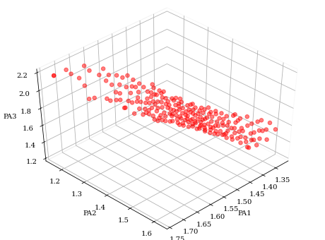

```python
plot = Scatter(labels=["PA1", "PA2", "PA3"])
plot.add(res1_tri.F, s= 30, facecolors='r', edgecolors='r', alpha = 0.5)
plot.save("front_tri_AGE.pdf")
plot.show()

res1_tri.F.shape
```

Evaluating convergence through hypervolume.

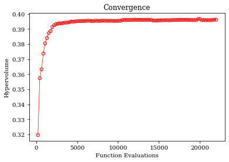

```python
n_evals1 = []
F1 = []
cv1 = []

for algorithm in res1_tri.history:
    n_evals1.append(algorithm.evaluator.n_eval)
    opt = algorithm.opt
    feas = np.where(opt.get("feasible"))[0]
    _F = opt.get("F")[feas]
    F1.append(_F)

ref_point = np.array([2,2,2])
metric = Hypervolume(ref_point=ref_point, normalize=False)
hv1 = [metric.do(f) for f in F1]

plt.figure()
plt.plot(n_evals1, hv1,  color='r', lw=0.7, label="Avg. CV of Pop")
plt.scatter(n_evals1, hv1,  facecolor="none", edgecolor='r', marker="p")
plt.title("Convergence")
plt.xlabel("Function Evaluations")
plt.ylabel("Hypervolume")
plt.show()

#hv1
```

Defining algorithm NSGA3 to solve the three-objective problem.

```python
ref_dirs3 = get_reference_directions("das-dennis", 3, n_partitions=12)

X = np.random.random((220, problem_tri_obj.n_var))
pop = Population.new("X", X)
Evaluator().eval(problem_tri_obj, pop)

algorithm2 = NSGA3(pop_size=220,
                   ref_dirs=ref_dirs3,
                   sampling=X)
```

Solving through NSGA3.

```python
res2_tri = minimize(problem_tri_obj,
                    algorithm2,
                    ("n_gen", 100),
                    verbose=True,
                    seed=1,
                    save_history = True)
```

```
==========================================================================================
n_gen  |  n_eval  | n_nds  |     cv_min    |     cv_avg    |      eps      |   indicator
==========================================================================================
     1 |      220 |      9 |  0.000000E+00 |  0.000000E+00 |             - |             -
     2 |      440 |      3 |  0.000000E+00 |  0.000000E+00 |  1.1041659248 |         ideal
     3 |      660 |      1 |  0.000000E+00 |  0.000000E+00 |  0.0460343856 |         ideal
     4 |      880 |      3 |  0.000000E+00 |  0.000000E+00 |  1.0000000000 |         ideal
     5 |     1100 |      6 |  0.000000E+00 |  0.000000E+00 |  0.5495958717 |         ideal
     6 |     1320 |      3 |  0.000000E+00 |  0.000000E+00 |  0.0150624047 |         ideal
     7 |     1540 |      5 |  0.000000E+00 |  0.000000E+00 |  0.1303909022 |         ideal
     8 |     1760 |      8 |  0.000000E+00 |  0.000000E+00 |  0.2773635813 |         ideal
     9 |     1980 |     11 |  0.000000E+00 |  0.000000E+00 |  0.4069147244 |         ideal
    10 |     2200 |     11 |  0.000000E+00 |  0.000000E+00 |  0.1436498111 |         ideal
    11 |     2420 |     11 |  0.000000E+00 |  0.000000E+00 |  0.0384201806 |         ideal
    12 |     2640 |     14 |  0.000000E+00 |  0.000000E+00 |  0.0692812870 |         ideal
```

[output cut: 88 more lines]

Ploting the Pareto frontier.

```
<pymoo.visualization.scatter.Scatter at 0x7f438c82a760>
```

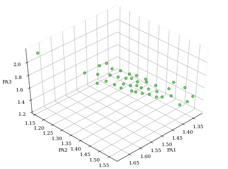

```python
plot = Scatter(labels=["PA1", "PA2", "PA3"])
plot.add(res2_tri.F, s= 30, facecolors='g', edgecolors='g', alpha = 0.5)
plot.save("front_tri_NSGA3.pdf")
plot.show()
```

Evaluating convergence through hypervolume.

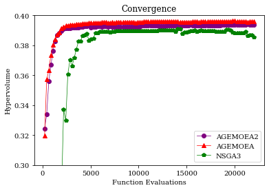

```python
n_evals2 = []
F2 = []
cv2 = []

for algorithm in res2_tri.history:
    n_evals2.append(algorithm.evaluator.n_eval)
    opt = algorithm.opt
    feas = np.where(opt.get("feasible"))[0]
    _F = opt.get("F")[feas]
    F2.append(_F)

metric = Hypervolume(ref_point=ref_point, normalize=False)
hv2 = [metric.do(f) for f in F2]

plt.figure()
plt.plot(n_evals, hv, 'o-', color='purple', lw=0.7, label="AGEMOEA2")
#plt.scatter(n_evals, hv,  facecolor="none", edgecolor='purple', marker="o", label="AGEMOEA2")
plt.plot(n_evals1, hv1, '^-', color='r', lw=0.7, label="AGEMOEA")
#plt.scatter(n_evals1, hv1,  facecolor="none", edgecolor='r', marker="^", label="AGEMOEA")
plt.plot(n_evals2, hv2, 'p-', color='g', lw=0.7, label="NSGA3")
#plt.scatter(n_evals2, hv2,  facecolor="none", edgecolor='g', marker="p", label="NSGA3")
plt.title("Convergence")
plt.xlabel("Function Evaluations")
plt.ylabel("Hypervolume")
plt.ylim([0.30, 0.40])
plt.legend()
plt.savefig("conv_tri.pdf")
plt.show()

#hv2
```

Selecting solutions of AGEMOEA through Pseudo-weights.

```
<pymoo.visualization.scatter.Scatter at 0x7f4387789820>
```

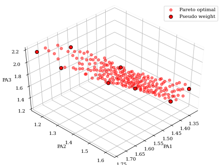

```python
w1 = np.array([1, 0, 0])
w2 = np.array([0, 1, 0])
w3 = np.array([0, 0, 1])
w4 = np.array([2/3, 1/3, 0])
w5 = np.array([2/3, 0, 1/3])
w6 = np.array([1/3, 2/3, 0])
w7 = np.array([1/3, 0, 2/3])
w8 = np.array([0, 2/3, 1/3])
w9 = np.array([0, 1/3, 2/3])
w10 = np.array([1/3, 1/3, 1/3])

a, pw1 = PseudoWeights(w1).do(res1_tri.F, return_pseudo_weights=True)
b, pw2 = PseudoWeights(w2).do(res1_tri.F, return_pseudo_weights=True)
c, pw3 = PseudoWeights(w3).do(res1_tri.F, return_pseudo_weights=True)
d, pw4 = PseudoWeights(w4).do(res1_tri.F, return_pseudo_weights=True)
e, pw5 = PseudoWeights(w5).do(res1_tri.F, return_pseudo_weights=True)
f, pw6 = PseudoWeights(w6).do(res1_tri.F, return_pseudo_weights=True)
g, pw7 = PseudoWeights(w7).do(res1_tri.F, return_pseudo_weights=True)
h, pw8 = PseudoWeights(w8).do(res1_tri.F, return_pseudo_weights=True)
i, pw9 = PseudoWeights(w9).do(res1_tri.F, return_pseudo_weights=True)
j, pw10 = PseudoWeights(w10).do(res2_tri.F, return_pseudo_weights=True)

plot = Scatter(labels=["PA1", "PA2", "PA3"], legend = True)
plot.add(res1_tri.F, s= 30, facecolors='r', edgecolors='r', alpha = 0.5, label = "Pareto optimal")
plot.add(res1_tri.F[[a,b,c,d,e,f,g,h,i,j]], facecolors='r', color="black", s=50, label = "Pseudo weight")
plot.save("front_tri_age_pw.pdf")
plot.show()
```

Ploting the Pareto frontier through Parallel coordinate plot.

```
<pymoo.visualization.pcp.PCP at 0x7f438771e850>
```

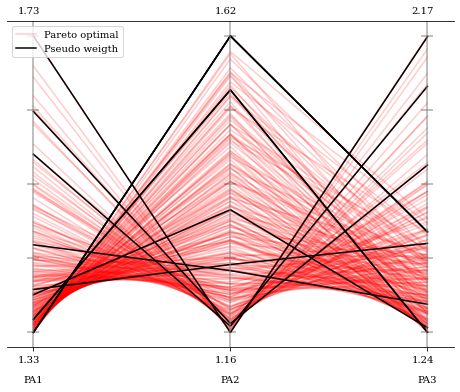

```python
plot = PCP(labels=["PA1", "PA2", "PA3"], legend = True)
plot.set_axis_style(color="grey", alpha=0.5)
plot.add(res1_tri.F, color='red', alpha = 0.2)
plot.add(res1_tri.F[1], color='red', alpha = 0.2, label = "Pareto optimal")
plot.add(res1_tri.F[[a,b,c,d,e,f,g,h,i,j]], color="black")
plot.add(res1_tri.F[[a]], color="black", label = "Pseudo weigth")
plot.save("pcp_tri_age2_pw.pdf")
plot.show()
```

Saving the results.

```python
weights = np.vstack((w1,w2,w3,w4,w5,w6,w7,w8,w9,w10))

fza = np.array(([res1_tri.X[[a,b,c,d,e,f,g,h,i,j],0]*(0.2-0.1)/2 + 0.15]))
fzt = np.array(([res1_tri.X[[a,b,c,d,e,f,g,h,i,j],1]*(0.2-0.1)/2 + 0.15]))
vc  = np.array(([res1_tri.X[[a,b,c,d,e,f,g,h,i,j],2]*(65-35)/2 + 50]))
X_unc = np.vstack((fza,fzt,vc)).T

res_tri = np.hstack((weights,res1_tri.X[[a,b,c,d,e,f,g,h,i,j]],X_unc,res1_tri.F[[a,b,c,d,e,f,g,h,i,j]]))
res_tri = np.around(res_tri, decimals = 2)

np.savetxt("res_tri.csv", res_tri, delimiter=',')
```

Defining the four objective problem. It is important to do that without run the three objective problem.

```python
class four_obj(ElementwiseProblem):

    def __init__(self):
        super().__init__(n_var=3, # numero de parametros
                         n_obj=4, # numero de funcoes objetivos
                         n_constr=1, # numero de restricoes
                         xl=np.array([-(2**3)**0.25, -(2**3)**0.25, -(2**3)**0.25]),
                         xu=np.array([(2**3)**0.25, (2**3)**0.25, (2**3)**0.25])
                         )

    def _evaluate(self, x, out, *args, **kwargs):
      # funcoes objetivo
      rmse1 = ((b0 + np.matmul(np.transpose([x[0],x[1],x[2]]),b) + np.matmul(np.matmul(np.transpose([x[0],x[1],x[2]]),B),[x[0],x[1],x[2]]) - TT)**2 + (mse + np.matmul(np.transpose(g + np.matmul(np.transpose(D),[x[0],x[1],x[2]])), (g + np.matmul(np.transpose(D),[x[0],x[1],x[2]])))))**0.5
      rmse2 = ((b02 + np.matmul(np.transpose([x[0],x[1],x[2]]),b2) + np.matmul(np.matmul(np.transpose([x[0],x[1],x[2]]),B2),[x[0],x[1],x[2]]) - TT2)**2 + (mse2 + np.matmul(np.transpose(g2 + np.matmul(np.transpose(D2),[x[0],x[1],x[2]])), (g2 + np.matmul(np.transpose(D2),[x[0],x[1],x[2]])))))**0.5
      rmse3 = ((b03 + np.matmul(np.transpose([x[0],x[1],x[2]]),b3) + np.matmul(np.matmul(np.transpose([x[0],x[1],x[2]]),B3),[x[0],x[1],x[2]]) - TT3)**2 + (mse3 + np.matmul(np.transpose(g3 + np.matmul(np.transpose(D3),[x[0],x[1],x[2]])), (g3 + np.matmul(np.transpose(D3),[x[0],x[1],x[2]])))))**0.5
      MRR = -250*4*(18**3/(8*10))*(x[2]*(65-35)/2 + 50)*(((x[0]*(0.2-0.1)/2 + 0.15)*10**-3)/(x[1]*(0.2-0.1)/2 + 0.15))*((((x[0]*(0.2-0.1)/2 + 0.15)*0.001)**2 + ((x[1]*(0.2-0.1)/2 + 0.15)*8/18)**2)**0.5)

      # restricao
      g1 = x[0]**2 + x[1]**2 + x[2]**2 - ((2**3)**0.25)**2

      out['F'] = [rmse1, rmse2, rmse3, MRR]
      out['G'] = [g1]

problem_four_obj = four_obj()
```

Solving the four-objective problem through AGEMOEA2.

```python
np.random.seed(10)

algorithm = AGEMOEA2(
    pop_size=220,
    n_offsprings=220,
    crossover=SBX(prob=0.9, eta=15),
    mutation=PM(eta=20),
    eliminate_duplicates=True)
```

```python
res_four = minimize(
  problem_four_obj,
  algorithm,
  ("n_gen", 100),
  verbose=True,
  #seed=1,
  save_history = True)
```

```
==========================================================================================
n_gen  |  n_eval  | n_nds  |     cv_min    |     cv_avg    |      eps      |   indicator
==========================================================================================
     1 |      220 |     21 |  0.000000E+00 |  0.6187457412 |             - |             -
     2 |      440 |     33 |  0.000000E+00 |  0.000000E+00 |  0.0105281285 |         ideal
     3 |      660 |     61 |  0.000000E+00 |  0.000000E+00 |  0.0604915872 |         ideal
     4 |      880 |     89 |  0.000000E+00 |  0.000000E+00 |  0.0228809613 |         ideal
     5 |     1100 |    155 |  0.000000E+00 |  0.000000E+00 |  0.0079365857 |         ideal
     6 |     1320 |    208 |  0.000000E+00 |  0.000000E+00 |  0.0161476270 |         ideal
     7 |     1540 |    220 |  0.000000E+00 |  0.000000E+00 |  0.0062700913 |         ideal
     8 |     1760 |    220 |  0.000000E+00 |  0.000000E+00 |  0.0123562831 |         nadir
     9 |     1980 |    220 |  0.000000E+00 |  0.000000E+00 |  0.0034850876 |         ideal
    10 |     2200 |    220 |  0.000000E+00 |  0.000000E+00 |  0.0025068212 |         ideal
    11 |     2420 |    220 |  0.000000E+00 |  0.000000E+00 |  0.0034854127 |         ideal
    12 |     2640 |    220 |  0.000000E+00 |  0.000000E+00 |  0.0078167291 |             f
```

[output cut: 88 more lines]

Plotting.

```
<pymoo.visualization.pcp.PCP at 0x7f43997212b0>
```

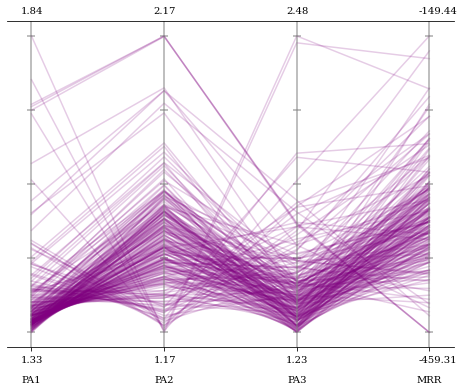

```python
plot = PCP(labels=["PA1", "PA2", "PA3", "MRR"])
plot.set_axis_style(color="grey", alpha=0.5)
plot.add(res_four.F, color='purple', alpha = 0.2)
plot.save("pcp_four_age2.pdf")
plot.show()
```

Evaluating convergence of AGEMOEA2.

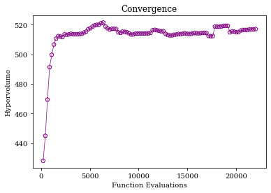

```python
n_evals = []
F = []
cv = []

for algorithm in res_four.history:
    n_evals.append(algorithm.evaluator.n_eval)
    opt = algorithm.opt
    feas = np.where(opt.get("feasible"))[0]
    _F = opt.get("F")[feas]
    F.append(_F)

ref_point = np.array([2,3,3,-160])
metric = Hypervolume(ref_point=ref_point, normalize=True)
hv = [metric.do(f) for f in F]

plt.figure()
plt.plot(n_evals, hv,  color='purple', lw=0.7, label="Avg. CV of Pop")
plt.scatter(n_evals, hv,  facecolor="none", edgecolor='purple', marker="p")
plt.title("Convergence")
plt.xlabel("Function Evaluations")
plt.ylabel("Hypervolume")
plt.show()

#hv
```

Solving the four-objective problem through AGEMOEA.

```python
np.random.seed(10)

algorithm1 = AGEMOEA(
    pop_size=220,
    n_offsprings=220,
    crossover=SBX(prob=0.9, eta=15),
    mutation=PM(eta=20),
    eliminate_duplicates=True)
```

```python
res1_four = minimize(
  problem_four_obj,
  algorithm1,
  ("n_gen", 100),
  verbose=True,
  seed=1,
  save_history = True)
```

```
==========================================================================================
n_gen  |  n_eval  | n_nds  |     cv_min    |     cv_avg    |      eps      |   indicator
==========================================================================================
     1 |      220 |     19 |  0.000000E+00 |  0.6549812232 |             - |             -
     2 |      440 |     30 |  0.000000E+00 |  0.000000E+00 |  0.3570767260 |         nadir
     3 |      660 |     59 |  0.000000E+00 |  0.000000E+00 |  0.0106714405 |         ideal
```

```
     4 |      880 |     86 |  0.000000E+00 |  0.000000E+00 |  0.0243466509 |         ideal
     5 |     1100 |    150 |  0.000000E+00 |  0.000000E+00 |  0.0251938328 |         ideal
     6 |     1320 |    220 |  0.000000E+00 |  0.000000E+00 |  0.0046589560 |         ideal
     7 |     1540 |    220 |  0.000000E+00 |  0.000000E+00 |  0.0026941474 |         ideal
     8 |     1760 |    220 |  0.000000E+00 |  0.000000E+00 |  0.0139699145 |             f
     9 |     1980 |    220 |  0.000000E+00 |  0.000000E+00 |  0.0088078352 |             f
    10 |     2200 |    220 |  0.000000E+00 |  0.000000E+00 |  0.0132859457 |         nadir
    11 |     2420 |    220 |  0.000000E+00 |  0.000000E+00 |  0.0043453656 |         ideal
    12 |     2640 |    220 |  0.000000E+00 |  0.000000E+00 |  0.0098732861 |             f
    13 |     2860 |    220 |  0.000000E+00 |  0.000000E+00 |  0.0073569999 |         ideal
    14 |     3080 |    220 |  0.000000E+00 |  0.000000E+00 |  0.0074704392 |             f
    15 |     3300 |    220 |  0.000000E+00 |  0.000000E+00 |  0.0076511781 |             f
    16 |     3520 |    220 |  0.000000E+00 |  0.000000E+00 |  0.0608956852 |         nadir
    17 |     3740 |    220 |  0.000000E+00 |  0.000000E+00 |  0.0062393604 |         nadir
    18 |     3960 |    220 |  0.000000E+00 |  0.000000E+00 |  0.0035954088 |         nadir
```

[output cut: 82 more lines]

```
<pymoo.visualization.pcp.PCP at 0x7f53015fdc70>
```

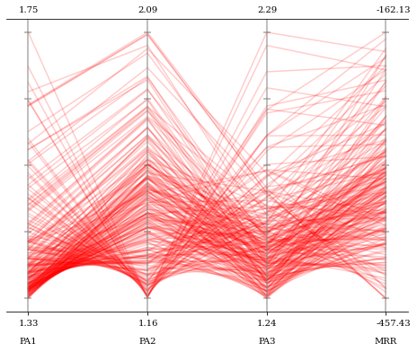

```python
plot = PCP(labels=["PA1", "PA2", "PA3", "MRR"])
plot.set_axis_style(color="grey", alpha=0.5)
plot.add(res1_four.F, color='red', alpha = 0.2)
plot.save("pcp_four_age.pdf")
plot.show()
```

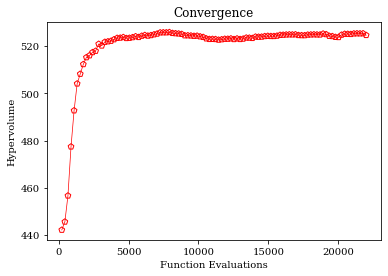

```python
n_evals1 = []
F1 = []
cv1 = []

for algorithm in res1_four.history:
    n_evals1.append(algorithm.evaluator.n_eval)
    opt = algorithm.opt
    feas = np.where(opt.get("feasible"))[0]
    _F = opt.get("F")[feas]
    F1.append(_F)

ref_point = np.array([2,3,3,-160])
metric = Hypervolume(ref_point=ref_point, normalize=False)
hv1 = [metric.do(f) for f in F1]

plt.figure()
plt.plot(n_evals1, hv1,  color='r', lw=0.7, label="Avg. CV of Pop")
plt.scatter(n_evals1, hv1,  facecolor="none", edgecolor='r', marker="p")
plt.title("Convergence")
plt.xlabel("Function Evaluations")
plt.ylabel("Hypervolume")
plt.show()

#hv1
```

Solving the four-objective problem through NSGA3.

```python
ref_dirs3 = get_reference_directions("das-dennis", 4, n_partitions=9)

X = np.random.random((220, problem_four_obj.n_var))
pop = Population.new("X", X)
Evaluator().eval(problem_four_obj, pop)

algorithm2 = NSGA3(pop_size=220,
                   ref_dirs=ref_dirs3,
                   sampling=X)
```

```python
res2_four = minimize(problem_four_obj,
                    algorithm2,
                    ("n_gen", 100),
                    verbose=True,
                    seed=1,
                    save_history = True)
```

```
==========================================================================================
n_gen  |  n_eval  | n_nds  |     cv_min    |     cv_avg    |      eps      |   indicator
==========================================================================================
     1 |      220 |     13 |  0.000000E+00 |  0.000000E+00 |             - |             -
     2 |      440 |     16 |  0.000000E+00 |  0.000000E+00 |  0.1173864717 |         ideal
     3 |      660 |     14 |  0.000000E+00 |  0.000000E+00 |  0.2158364717 |         ideal
     4 |      880 |     14 |  0.000000E+00 |  0.000000E+00 |  0.2777459324 |         ideal
     5 |     1100 |     15 |  0.000000E+00 |  0.000000E+00 |  0.2110838716 |         ideal
     6 |     1320 |     19 |  0.000000E+00 |  0.000000E+00 |  0.1613567461 |         ideal
     7 |     1540 |     18 |  0.000000E+00 |  0.000000E+00 |  0.0557991201 |         ideal
     8 |     1760 |     18 |  0.000000E+00 |  0.000000E+00 |  0.1121508866 |         ideal
     9 |     1980 |     24 |  0.000000E+00 |  0.000000E+00 |  0.0393638268 |         ideal
    10 |     2200 |     20 |  0.000000E+00 |  0.000000E+00 |  0.0597693716 |         ideal
    11 |     2420 |     26 |  0.000000E+00 |  0.000000E+00 |  0.0685048592 |         ideal
    12 |     2640 |     25 |  0.000000E+00 |  0.000000E+00 |  0.0112994996 |         ideal
```

[output cut: 88 more lines]

```
<pymoo.visualization.pcp.PCP at 0x7f437ef6ba90>
```

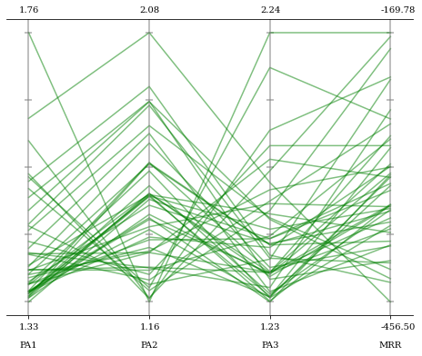

```python
plot = PCP(labels=["PA1", "PA2", "PA3", "MRR"])
plot.set_axis_style(color="grey", alpha=0.5)
plot.add(res2_four.F, color='green', alpha = 0.5)
plot.save("pcp_four_nsga3.pdf")
plot.show()
```

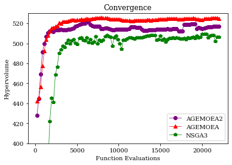

```python
n_evals2 = []
F2 = []
cv2 = []

for algorithm in res2_four.history:
    n_evals2.append(algorithm.evaluator.n_eval)
    opt = algorithm.opt
    feas = np.where(opt.get("feasible"))[0]
    _F = opt.get("F")[feas]
    F2.append(_F)

metric = Hypervolume(ref_point=ref_point, normalize=False)
hv2 = [metric.do(f) for f in F2]

plt.figure()
plt.plot(n_evals, hv, 'o-', color='purple', lw=0.7, label="AGEMOEA2")
#plt.scatter(n_evals, hv,  facecolor="none", edgecolor='purple', marker="p")
plt.plot(n_evals1, hv1, '^-', color='r', lw=0.7, label="AGEMOEA")
#plt.scatter(n_evals1, hv1,  facecolor="none", edgecolor='r', marker="p")
plt.plot(n_evals2, hv2, 'p-', color='g', lw=0.7, label="NSGA3")
#plt.scatter(n_evals2, hv2,  facecolor="none", edgecolor='g', marker="p")
plt.title("Convergence")
plt.xlabel("Function Evaluations")
plt.ylabel("Hypervolume")
plt.ylim([400,530])
plt.legend()
plt.savefig("conv_four.pdf")
plt.show()

#hv2
```

```
<pymoo.visualization.scatter.Scatter at 0x7f52fcb506d0>
```

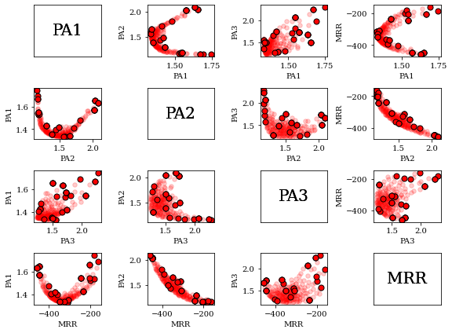

```python
w1 = np.array([1, 0, 0, 0])
w2 = np.array([0.75, 0.25, 0, 0])
w3 = np.array([0.50, 0.50, 0, 0])
w4 = np.array([0.25, 0.75, 0, 0])
w5 = np.array([0, 1, 0, 0])
w6 = np.array([0.75, 0, 0.25, 0])
w7 = np.array([0.50, 0.25, 0.25, 0])
w8 = np.array([0.25, 0.50, 0.25, 0])
w9 = np.array([0, 0.75, 0.25, 0])
w10 = np.array([0.50, 0, 0.50, 0])
w11 = np.array([0.25, 0.25, 0.50, 0])
w12 = np.array([0, 0.50, 0.50, 0])
w13 = np.array([0.25, 0, 0.75, 0])
w14 = np.array([0, 0.25, 0.75, 0])
w15 = np.array([0, 0, 1, 0])
w16 = np.array([0.75, 0, 0, 0.25])
w17 = np.array([0.50, 0.25, 0, 0.25])
w18 = np.array([0.25, 0.50, 0, 0.25])
w19 = np.array([0, 0.75, 0, 0.25])
w20 = np.array([0.50, 0, 0.25, 0.25])
w21 = np.array([0.25, 0.25, 0.25, 0.25])
w22 = np.array([0, 0.50, 0.25, 0.25])
w23 = np.array([0.25, 0, 0.50, 0.25])
w24 = np.array([0, 0.25, 0.50, 0.25])
w25 = np.array([0, 0, 0.75, 0.25])
w26 = np.array([0.50, 0, 0, 0.50])
w27 = np.array([0.25, 0.25, 0, 0.50])
w28 = np.array([0, 0.50, 0, 0.50])
w29 = np.array([0.25, 0, 0.25, 0.50])
w30 = np.array([0, 0.25, 0.25, 0.50])
w31 = np.array([0, 0, 0.50, 0.50])
w32 = np.array([0.25, 0, 0, 0.75])
w33 = np.array([0, 0.25, 0, 0.75])
w34 = np.array([0, 0, 0.25, 0.75])
w35 = np.array([0 ,0, 0, 1])

a, pw1 = PseudoWeights(w1).do(res1_four.F, return_pseudo_weights=True)
b, pw2 = PseudoWeights(w2).do(res1_four.F, return_pseudo_weights=True)
c, pw3 = PseudoWeights(w3).do(res1_four.F, return_pseudo_weights=True)
d, pw4 = PseudoWeights(w4).do(res1_four.F, return_pseudo_weights=True)
e, pw5 = PseudoWeights(w5).do(res1_four.F, return_pseudo_weights=True)
f, pw6 = PseudoWeights(w6).do(res1_four.F, return_pseudo_weights=True)
g, pw7 = PseudoWeights(w7).do(res1_four.F, return_pseudo_weights=True)
h, pw8 = PseudoWeights(w8).do(res1_four.F, return_pseudo_weights=True)
i, pw9 = PseudoWeights(w9).do(res1_four.F, return_pseudo_weights=True)
j, pw10 = PseudoWeights(w10).do(res1_four.F, return_pseudo_weights=True)
k, pw11 = PseudoWeights(w11).do(res1_four.F, return_pseudo_weights=True)
l, pw12 = PseudoWeights(w12).do(res1_four.F, return_pseudo_weights=True)
m, pw10 = PseudoWeights(w13).do(res1_four.F, return_pseudo_weights=True)
n, pw10 = PseudoWeights(w14).do(res1_four.F, return_pseudo_weights=True)
o, pw10 = PseudoWeights(w15).do(res1_four.F, return_pseudo_weights=True)
p, pw10 = PseudoWeights(w16).do(res1_four.F, return_pseudo_weights=True)
q, pw10 = PseudoWeights(w17).do(res1_four.F, return_pseudo_weights=True)
r, pw10 = PseudoWeights(w18).do(res1_four.F, return_pseudo_weights=True)
s, pw10 = PseudoWeights(w19).do(res1_four.F, return_pseudo_weights=True)
t, pw10 = PseudoWeights(w20).do(res1_four.F, return_pseudo_weights=True)
u, pw10 = PseudoWeights(w21).do(res1_four.F, return_pseudo_weights=True)
v, pw10 = PseudoWeights(w22).do(res1_four.F, return_pseudo_weights=True)
w, pw10 = PseudoWeights(w23).do(res1_four.F, return_pseudo_weights=True)
x, pw10 = PseudoWeights(w24).do(res1_four.F, return_pseudo_weights=True)
y, pw10 = PseudoWeights(w25).do(res1_four.F, return_pseudo_weights=True)
z, pw10 = PseudoWeights(w26).do(res1_four.F, return_pseudo_weights=True)
aa, pw10 = PseudoWeights(w27).do(res1_four.F, return_pseudo_weights=True)
bb, pw10 = PseudoWeights(w28).do(res1_four.F, return_pseudo_weights=True)
cc, pw10 = PseudoWeights(w29).do(res1_four.F, return_pseudo_weights=True)
dd, pw10 = PseudoWeights(w30).do(res1_four.F, return_pseudo_weights=True)
ee, pw10 = PseudoWeights(w31).do(res1_four.F, return_pseudo_weights=True)
ff, pw10 = PseudoWeights(w32).do(res1_four.F, return_pseudo_weights=True)
gg, pw10 = PseudoWeights(w33).do(res1_four.F, return_pseudo_weights=True)
hh, pw10 = PseudoWeights(w34).do(res1_four.F, return_pseudo_weights=True)
ii, pw10 = PseudoWeights(w35).do(res1_four.F, return_pseudo_weights=True)

plot = Scatter(labels=["PA1", "PA2", "PA3", "MRR"],tight_layout=True)
plot.add(res1_four.F, s= 30, facecolors='r', edgecolors='r', alpha = 0.2)
plot.add(res1_four.F[[a,b,c,d,e,f,g,h,i,j,k,l,m,n,o,p,q,r,s,t,u,v,w,x,y,z,aa,bb,cc,dd,ee,ff,gg,hh,ii]], facecolors='r', color="black", s=50)
plot.save("sc_front_four.pdf")
plot.show()
```

```
<pymoo.visualization.pcp.PCP at 0x7f52fc7aee20>
```

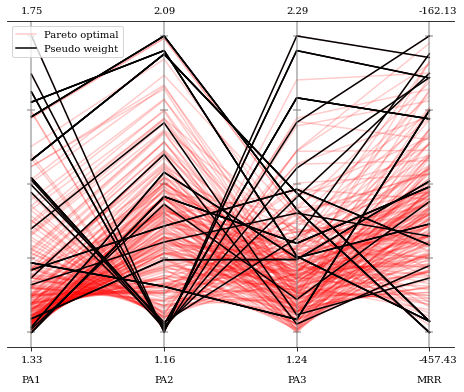

```python
plot = PCP(labels=["PA1", "PA2", "PA3", "MRR"], legend = True)
plot.set_axis_style(color="grey", alpha=0.5)
plot.add(res1_four.F, color='red', alpha = 0.2)
plot.add(res1_four.F[1], color='red', alpha = 0.2, label = "Pareto optimal")
plot.add(res1_four.F[[a,b,c,d,e,f,g,h,i,j,k,l,m,n,o,p,q,r,s,t,u,v,w,x,y,z,aa,bb,cc,dd,ee,ff,gg,hh,ii]], color="black")
plot.add(res1_four.F[[a]], color="black", label = "Pseudo weight")
plot.save("pcp_four_age_pw.pdf")
plot.show()
```

```
<pymoo.visualization.heatmap.Heatmap at 0x7f52fbf26490>
```

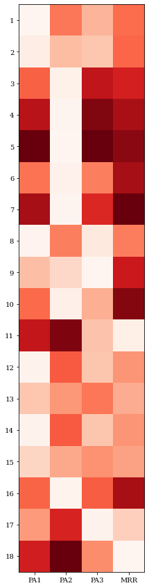

```python
plot = Heatmap(labels=["PA1", "PA2", "PA3", "MRR"], cmap="Reds_r", figsize=(5,15))
plot.add(res1_four.F[[a,b,c,d,e, h,i,j,k,l, o,p,q, t,u,v,w, ii]])
plot.show()
```

Saving the results.

```python
weights4 = np.vstack((w1,w2,w3,w4,w5,w6,w7,w8,w9,w10,w11,w12,w13,w14,w15,w16,w17,w18,w19,w20,w21,w22,w23,w24,w25,w26,w27,w28,w29,w30,w31,w32,w33,w34,w35))

fza4 = np.array(([res1_four.X[[a,b,c,d,e,f,g,h,i,j,k,l,m,n,o,p,q,r,s,t,u,v,w,x,y,z,aa,bb,cc,dd,ee,ff,gg,hh,ii],0]*(0.2-0.1)/2 + 0.15]))
fzt4 = np.array(([res1_four.X[[a,b,c,d,e,f,g,h,i,j,k,l,m,n,o,p,q,r,s,t,u,v,w,x,y,z,aa,bb,cc,dd,ee,ff,gg,hh,ii],1]*(0.2-0.1)/2 + 0.15]))
vc4  = np.array(([res1_four.X[[a,b,c,d,e,f,g,h,i,j,k,l,m,n,o,p,q,r,s,t,u,v,w,x,y,z,aa,bb,cc,dd,ee,ff,gg,hh,ii],2]*(65-35)/2 + 50]))
X_unc4 = np.vstack((fza4,fzt4,vc4)).T

res_4 = np.hstack((weights4,
                   res1_four.X[[a,b,c,d,e,f,g,h,i,j,k,l,m,n,o,p,q,r,s,t,u,v,w,x,y,z,aa,bb,cc,dd,ee,ff,gg,hh,ii]],
                   X_unc4,
                   res1_four.F[[a,b,c,d,e,f,g,h,i,j,k,l,m,n,o,p,q,r,s,t,u,v,w,x,y,z,aa,bb,cc,dd,ee,ff,gg,hh,ii]]))
res_4 = np.around(res_4, decimals = 2)

np.savetxt("res_four.csv", res_4, delimiter=',')
```